# 2020 F1 Results: Data Prep & Visualization in R

Andrew Amore

### Abstract

Data from the 2020 Formula 1 racing season was downloaded from ergast.com, the official API of F1, containing results from the 17 race season. The information returned from the API call is messy, hard to interpret, and deeply nested. To make the results more interpretable a dplyr data cleaning pipeline was implemented to flatten the table structure with only necessary fields.

To enhance a viewers ability to interpret the tabular results two graphics were built to show driver and constructor performance over the season. The driver graphic clearly shows the dominance of Mercedes.

### Part 1 - Data Prep

An example API call, with only one race result, and code to explain how the JSON payload was saved to a local flat file.

```r
samp_res = GET("https://ergast.com/api/f1/2020/results.json?limit=1?callback=myParser")
f1_samp = fromJSON(rawToChar(samp_res$content))
saveRDS(f1_samp, "./data/f1_samp.rds")
```

The raw structure is very nested and needs to be expanded. A full extraction was saved locally and used for visualization called ./data/f1.rds. The nested structure can be seen from the R data viewer.

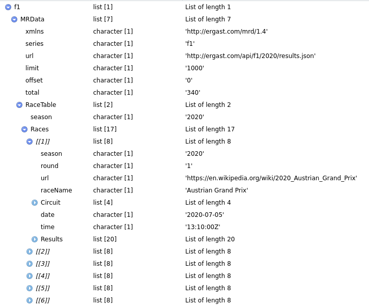

To make this format more plot friendly it needs to be cleaned. First, I manually identified the most “granular” nested item from the f1 object: races. To correctly format the nested structure I converted races to a tibble and leveraged various dplyr functions making use of hoist to cut down on unnecessary unnest_wider calls. The top 10 rows were displayed using head.

```r
f1 = readRDS(file="data/f1.rds")
val = f1$MRData$RaceTable$Races
# convert to tibble
val = tibble::tibble(val)
# dplyr pipeline start
val = val %>% hoist(
  val,
  race_name = "raceName",
  round = "round",
  date = "date",
  results = "Results"
) %>% # elongate results for each race at driver level
  unnest_longer(results) %>%
  # hoist again to extract final table
  hoist(
    results,
    givenName = c("Driver", "givenName"),
    familyName = c("Driver", "familyName"),
    name = c("Constructor", "name"),
    position = "positionText",
    points = "points"
  ) %>% # concatenate driver name
  mutate(driver = paste(givenName, familyName, sep = " "),
         position = case_when(
          position == 'R' ~ as.character(NA), #"Ret",
          position == 'D' ~ as.character(NA), #"DQ",
          position == 'E' ~ as.character(NA), #"Excluded",
          position == 'W' ~ as.character(NA), #"WD",
          position == 'F' ~ as.character(NA), #"FTQ",
          position == 'N' ~ as.character(NA), #"NC",
          TRUE ~ position
         )) %>%
  select(race_name,
         round,
         date,
         driver,
         name,
         position,
         points) %>%
  rename(constructor = name)

# format and print table
val %>% head(., 10) %>%
  kbl(caption = "Cleaned Results Table") %>%
  kable_material(c("striped", "hover"))
```

Cleaned Results Table

| race_name | round | date | driver | constructor | position | points |
| --- | --- | --- | --- | --- | --- | --- |
| Austrian Grand Prix | 1 | 2020-07-05 | Valtteri Bottas | Mercedes | 1 | 25 |
| Austrian Grand Prix | 1 | 2020-07-05 | Charles Leclerc | Ferrari | 2 | 18 |
| Austrian Grand Prix | 1 | 2020-07-05 | Lando Norris | McLaren | 3 | 16 |
| Austrian Grand Prix | 1 | 2020-07-05 | Lewis Hamilton | Mercedes | 4 | 12 |
| Austrian Grand Prix | 1 | 2020-07-05 | Carlos Sainz | McLaren | 5 | 10 |
| Austrian Grand Prix | 1 | 2020-07-05 | Sergio Pérez | Racing Point | 6 | 8 |
| Austrian Grand Prix | 1 | 2020-07-05 | Pierre Gasly | AlphaTauri | 7 | 6 |
| Austrian Grand Prix | 1 | 2020-07-05 | Esteban Ocon | Renault | 8 | 4 |
| Austrian Grand Prix | 1 | 2020-07-05 | Antonio Giovinazzi | Alfa Romeo | 9 | 2 |
| Austrian Grand Prix | 1 | 2020-07-05 | Sebastian Vettel | Ferrari | 10 | 1 |

### Part 2 - Visualization

F1 is a truly unique sport combining the marvels of modern engineering with some of the most gifted reflex-based athletes in the world. Many people might not be aware of the resource disparities which exist between teams who compete in the same races for the same championship crown. Just how unequal are these teams in terms of the seasonal F1 points system awarded based on final race position? This visualization hopes to display how F1 is dominated by the top team(s) by displaying the performance of drivers and teams in the 2020 F1 season. Two charts were created for this purpose:

**Spiral Team Chart (A):**  
Team performance through each race is displayed using a circular bar plot. Race abbreviations, denoted along the outside edge, start from 1:00 and move clockwise around the circle in order of race occurrence. Points for each driver are aggregated by team, cumulatively summed over the season, and shown by color. This chart clearly shows the dominance by team Mercedes over the season as the color largest block in each race is affiliated with this team. We see this percentage remain relatively constant from the first few races of the season all the way to the finale.

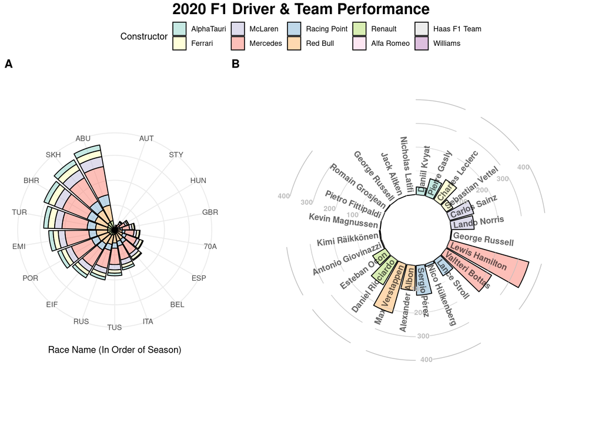

```r
############### plot1 - team performance by race (spiral bar) ###############
season = val %>% ungroup() %>%
  group_by(race_name, date, constructor) %>%
  summarise(season_points = sum(points)) %>%
  arrange(date) %>% ungroup() %>% group_by(constructor) %>%
  inner_join(season_rank, by = "constructor") %>%
  mutate(cum_points = cumsum(season_points)) %>%
  select(-season_point_total)

# assign integer denoting order race occurred during season
race_int = val %>% distinct(race_name, date) %>%
  mutate(race_num = rank(date))%>% select(-date)
team_cir = season %>% inner_join(race_int, by = "race_name") %>%
  arrange(race_num, cum_points)

# reorder factors for legend ordering
team_cir$constructor <-
  factor(
    team_cir$constructor,
    levels = c(
      "AlphaTauri", "Ferrari",
      "McLaren", "Mercedes",
      "Racing Point", "Red Bull",
      "Renault", "Alfa Romeo",
      "Haas F1 Team", "Williams"
    )
  )

# create data structure for the plot labels
racelabs = c(
  'AUT', 'STY',
  'HUN', 'GBR',
  '70A', 'ESP',
  'BEL', 'ITA',
  'TUS', 'RUS',
  'EIF', 'POR',
  'EMI', 'TUR',
  'BHR', 'SKH',
  'ABU'
)

# plot
fraction_plt = ggplot(team_cir, aes(x = race_num, y = cum_points,
                                    fill = constructor)) +
  geom_col(alpha = 0.5, colour = "black") +
  scale_fill_brewer(palette = "Set3") +
  theme_bw() +
  theme(
    panel.border = element_blank(),
    axis.title.y = element_blank(),
    axis.text.y = element_blank(),
    axis.ticks.y = element_blank(),
    plot.title = element_text(hjust = 0.5)
  ) +
  coord_polar() +
  scale_x_continuous(limits = c(1, 18)) +
  guides(fill = guide_legend(title = "Constructor")) +
  xlab("Race Name (In Order of Season)") +
  ylab("Cumulative Points through Each Race")  +
  # set the rotational axis labels to be the race names
  scale_x_discrete(limits = c(seq(
    from = 1, to = 17, by = 1
  )), labels = racelabs)


############# plot2 - individual driver performance (spiral bar) #############
# chart inspiration and some source code::
# https://www.r-graph-gallery.com/299-circular-stacked-barplot.html

## stacked bar chart...driver with team
stcked = val %>% group_by(driver, constructor) %>%
  summarise(season_points = sum(points))

data = stcked %>% gather(key = "observation", value = "value", -c(1, 2))

# set ordering for consistency between chart legends
data$constructor <-
  factor(
    data$constructor,
    levels = c(
      "AlphaTauri", "Ferrari",
      "McLaren", "Mercedes",
      "Racing Point", "Red Bull",
      "Renault", "Alfa Romeo",
      "Haas F1 Team", "Williams"
    )
  )

# controls "dart board" arc lengths and label orientation
empty_bar <- 2.5
data <- data %>% arrange(constructor, driver)
data$id <- rep(seq(1, nrow(data) / 1) , each = 1)
# sets label location on chart
label_data <-
  data %>% group_by(id, driver) %>% summarize(tot = sum(value))
number_of_bar <- nrow(label_data)
angle <- 90 - 360 * (label_data$id - 0.5) / number_of_bar
label_data$hjust <- ifelse(angle < -90, 1, 0)
label_data$angle <- ifelse(angle < -90, angle + 180, angle)
# converts data into correct format
base_data <- data %>%
  group_by(constructor) %>%
  summarize(start = min(id), end = max(id) - empty_bar) %>%
  rowwise() %>%
  mutate(title = mean(c(start, end)))

# this sets location for team labels around the interior
grid_data <- base_data
grid_data$end <-
  grid_data$end[c(nrow(grid_data), 1:nrow(grid_data) - 1)] + 1
grid_data$start <- grid_data$start - 1
grid_data <- grid_data[-1,]

driver_plt = ggplot(data) +
  # Add the stacked bar
  geom_bar(
    aes(x = as.factor(id), y = value, fill = constructor),
    stat = "identity",
    alpha = 0.5,
    colour = "black"
  ) +
  scale_fill_brewer(palette = "Set3") +

  ## add tick marks (dart board lines) denoting the season point totals
  geom_segment(
    data = grid_data,
    aes(
      x = end,
      y = 0,
      xend = start,
      yend = 0
    ),
    colour = "grey",
    alpha = 1,
    size = 0.1 ,
    inherit.aes = FALSE
  ) +
  geom_segment(
    data = grid_data,
    aes(
      x = end,
      y = 100,
      xend = start,
      yend = 100
    ),
    colour = "grey",
    alpha = 1,
    size = 0.1 ,
    inherit.aes = FALSE
  ) +
  geom_segment(
    data = grid_data,
    aes(
      x = end,
      y = 200,
      xend = start,
      yend = 200
    ),
    colour = "grey",
    alpha = 1,
    size = 0.2 ,
    inherit.aes = FALSE
  ) +
  geom_segment(
    data = grid_data,
    aes(
      x = end,
      y = 300,
      xend = start,
      yend = 300
    ),
    colour = "grey",
    alpha = 1,
    size = 0.3 ,
    inherit.aes = FALSE
  ) +
  geom_segment(
    data = grid_data,
    aes(
      x = end,
      y = 400,
      xend = start,
      yend = 400
    ),
    colour = "grey",
    alpha = 1,
    size = 0.4 ,
    inherit.aes = FALSE
  ) +
  ##

  # tick mark labels
  ggplot2::annotate(
    "text",
    x = rep(max(data$id) / 2, 4),
    y = c(100, 200, 300, 400),
    label = c("100", "200", "300", "400") ,
    color = "grey",
    size = 3 ,
    angle = 0,
    fontface = "bold",
    hjust = 1
  ) +
  ggplot2::annotate(
    "text",
    x = rep(max(data$id) / 1.23, 4),
    y = c(100, 200, 300, 400),
    label = c("100", "200", "300", "400") ,
    color = "grey",
    size = 3 ,
    angle = 0,
    fontface = "bold",
    hjust = 1
  ) +
  ggplot2::annotate(
    "text",
    x = rep(max(data$id) / 5.25, 4),
    y = c(100, 200, 300, 400),
    label = c("100", "200", "300", "400") ,
    color = "grey",
    size = 3 ,
    angle = 0,
    fontface = "bold",
    hjust = 1
  ) +

  # tick mark range
  ylim(-150, 425) +
  theme_minimal() +
  theme(
    legend.position = "none",
    axis.text = element_blank(),
    axis.title = element_blank(),
    panel.grid = element_blank()
  ) +
  coord_polar() +
  # Add labels for each bar (driver names)
  geom_text(
    data = label_data,
    aes(
      x = id,
      y = 10,
      label = driver,
      hjust = hjust
    ),
    color = "black",
    fontface = "bold",
    alpha = 0.6,
    size = 3.5,
    angle = label_data$angle,
    inherit.aes = FALSE
  )

# arrange plots
plot = ggarrange(
  fraction_plt,
  driver_plt,
  ncol = 2,
  nrow = 1,
  common.legend = TRUE,
  legend = "top",
  widths = c(1, 1.65),
  heights = c(1, 1.65),
  align = "hv",
  labels = "AUTO"
)
# add main title to figure
annotate_figure(plot,
                top = text_grob(
                  "2020 F1 Driver & Team Performance",
                  color = "black",
                  face = "bold",
                  size = 18
                ))
```